# Forest Cover Classification

### Initial Data Exploration

[figure not shown]

### The dataset

This dataset contains observations of a selection of geographic data on 30 x 30 meter cells located in the Roosevelt National Forest of northern Colorado.  
There are 581,012 observations of 12 independent variables.  
The aim of this project is to develop a model that can accurately predict what type of forest cover a 30m x 30m cell in any area *similar* to the Roosevelt National Forest has, based on measurements of it's elevation; aspect; distance to water, roads and firepoints; hillshade; and soil type.

Independent variables were derived from data originally obtained from US Geological Survey (USGS) and USFS data.

| Feature | Type | Measurement | Description |
| --- | --- | --- | --- |
| Elevation | Quantitative | Meters | Elevation in meters |
| Aspect | Quantitative | Azimuth | Aspect in degrees azimuth |
| Slope | Quantitative | Degrees | Slope in degrees |
| Horizontal Distance To Hydrology | Quantitative | Meters | Horizontal distance to nearest surface water features |
| Vertical Distance To Hydrology | Quantitative | Meters | Vertical distance to nearest surface water features |
| Horizontal Distance To Roadway | Quantitative | Meters | Horizontal distance to nearest roadway |
| Hillshade 9am | Quantitative | ArcGIS index, 0 to 255 | Hillshade index at 9am, summer solstice |
| Hillshade Noon | Quantitative | ArcGIS index, 0 to 255 | Hillshade index at noon, summer solstice |
| Hillshade 3pm | Quantitative | ArcGIS index, 0 to 255 | Hillshade index at 3pm, summer solstice |
| Horizontal Distance To Fire Points | Quantitative | Meters | Horizontal distance to nearest wildfire ignition points |
| Wilderness Area<sup>1</sup> | Qualitative | Boolean (4 one-hot columns) | Wilderness area designation |
| Soil Type<sup>2</sup> | Qualitative | Boolean (40 one-hot columns) | Soil type designation |
| Cover Type<sup>3</sup> | Qualitative | Integer, bewteen 1 and 7 | Forest cover type designation |

**<sup>1</sup>** The set includes data from four wilderness areas located in the Roosevelt National Forest of northern Colorado. These areas represent forests with minimal human-caused disturbances, so that existing forest cover types are more a result of ecological processes rather than forest management practices.

1. Rawah Wilderness Area
2. Neota Wilderness Area
3. Comanche Peak Wilderness Area
4. Cache la Poudre Wilderness Area

**<sup>2</sup>** The soil type is based on a USFS Ecological survey, and there are 40 distinct values. Each code in the dataset is associated with a USFS ELU Code and a description as per the table below. The first and second digits of the USFS ELU Code represent a climatic zone and geologic zone respectively.

| Dataset Code | USFS ELU Code | Description |
| --- | --- | --- |
| 1 | 2702 | Catdedral family - Rock outcrop complex, extremely stony. |
| 2 | 2703 | Vanet - Ratake families complex, very stony. |
| 3 | 2704 | Haploborolis - Rock outcrop complex, rubbly. |
| 4 | 2705 | Ratake family - Rock outcrop complex, rubbly. |
| 5 | 2706 | Vanet family - Rock outcrop complex complex, rubbly. |
| 6 | 2717 | Vanet - Wetmore families - Rock outcrop complex, stony. |
| 7 | 3501 | Gotdic family. |
| 8 | 3502 | Supervisor - Limber families complex. |
| 9 | 4201 | Troutville family, very stony. |
| 10 | 4703 | Bullwark - Catamount families - Rock outcrop complex, rubbly. |
| 11 | 4704 | Bullwark - Catamount families - Rock land complex, rubbly. |
| 12 | 4744 | Legault family - Rock land complex, stony. |
| 13 | 4758 | Catamount family - Rock land - Bullwark family complex, rubbly. |
| 14 | 5101 | Pachic Argiborolis - Aquolis complex. |
| 15 | 5151 | Unspecified in tde USFS Soil and ELU Survey. |
| 16 | 6101 | Cryaquolis - Cryoborolis complex. |
| 17 | 6102 | Gateview family - Cryaquolis complex. |
| 18 | 6731 | Rogert family, very stony. |
| 19 | 7101 | Typic Cryaquolis - Borohemists complex. |
| 20 | 7102 | Typic Cryaquepts - Typic Cryaquolls complex. |
| 21 | 7103 | Typic Cryaquolls - Leighcan family, till substratum complex. |
| 22 | 7201 | Leighcan family, till substratum, extremely bouldery. |
| 23 | 7202 | Leighcan family, till substratum - Typic Cryaquolls complex. |
| 24 | 7700 | Leighcan family, extremely stony. |
| 25 | 7701 | Leighcan family, warm, extremely stony. |
| 26 | 7702 | Granile - Catamount families complex, very stony. |
| 27 | 7709 | Leighcan family, warm - Rock outcrop complex, extremely stony. |
| 28 | 7710 | Leighcan family - Rock outcrop complex, extremely stony. |
| 29 | 7745 | Como - Legault families complex, extremely stony. |
| 30 | 7746 | Como family - Rock land - Legault family complex, extremely stony. |
| 31 | 7755 | Leighcan - Catamount families complex, extremely stony. |
| 32 | 7756 | Catamount family - Rock outcrop - Leighcan family complex, extremely stony. |
| 33 | 7757 | Leighcan - Catamount families - Rock outcrop complex, extremely stony. |
| 34 | 7790 | Cryortdents - Rock land complex, extremely stony. |
| 35 | 8703 | Cryumbrepts - Rock outcrop - Cryaquepts complex. |
| 36 | 8707 | Bross family - Rock land - Cryumbrepts complex, extremely stony. |
| 37 | 8708 | Rock outcrop - Cryumbrepts - Cryortdents complex, extremely stony. |
| 38 | 8771 | Leighcan - Moran families - Cryaquolls complex, extremely stony. |
| 39 | 8772 | Moran family - Cryortdents - Leighcan family complex, extremely stony. |
| 40 | 8776 | Moran family - Cryortdents - Rock land complex, extremely stony. |

First digit of USFS ELU Code: climatic zone

1. lower montane dry
2. lower montane
3. montane dry
4. montane
5. montane dry and montane
6. montane and subalpine
7. subalpine
8. alpine

Second digit of USFS ELU Code: geologic zone

1. alluvium
2. glacial
3. shale
4. sandstone
5. mixed sedimentary
6. unspecified in the USFS ELU Survey
7. igneous and metamorphic
8. volcanic

**<sup>3</sup>** There are 7 distinct values for the cover type, each of which contains information on which tree species makes up the bulk of the forest cover for the area.

1. Spruce/Fir
2. Lodgepole Pine
3. Ponderosa Pine
4. Cottonwood/Willow
5. Aspen
6. Douglas-fir
7. Krummholz

The dataset was sourced from the [Center for Machine Learning and Intelligent Systems, University of California Irvine](https://archive.ics.uci.edu/ml/datasets/Covertype)  
The original owners of the data are:

Remote Sensing and GIS Program  
Department of Forest Sciences  
College of Natural Resources  
Colorado State University  
Fort Collins, CO 80523  
(contact Jock A. Blackard, jblackard '@' fs.fed.us or Dr. Denis J. Dean, denis.dean '@' utdallas.edu)

Donors of database:

1. Jock A. Blackard (jblackard@fs.fed.us)  
   GIS Coordinator  
   USFS - Forest Inventory & Analysis  
   Rocky Mountain Research Station  
   507 25th Street  
   Ogden, UT 84401
2. Dr. Denis J. Dean (denis.dean@utdallas.edu)  
   Professor  
   Program in Geography and Geospatial Sciences  
   School of Economic, Political and Policy Sciences  
   800 West Campbell Rd  
   Richardson, TX 75080-3021
3. Dr. Charles W. Anderson (anderson@cs.colostate.edu)  
   Associate Professor  
   Department of Computer Science  
   Colorado State University  
   Fort Collins, CO 80523 USA

### Extract data and perform inital review

```python
# Import Libraries
import pandas as pd
import numpy as np
import matplotlib.pyplot as plt
import scipy.stats as stats

# Define a color list for plotting
color_list = ["#68c4a4", "#ff8c64", "#90a4cc", "#e88cc4", "#ffdc2c", "#a8dc54", "#e8c494"]

# Define directory
data_dir = "C:\\Users\\oliki\\OneDrive\\Forest Cover Classification\\"
```

```python
# Import data
file_name = "covtype.data"
features = ["elevation", "aspect", "slope", "hor_dist_to_hydro", "ver_dist_to_hydro","hor_dist_to_road", "hillshade_9am",
            "hillshade_noon", "hillshade_3pm","hor_dist_to_fire",
            "wilderness_area_1", "wilderness_area_2", "wilderness_area_3", "wilderness_area_4",
            "soil_type_1","soil_type_2","soil_type_3","soil_type_4","soil_type_5",
            "soil_type_6","soil_type_7","soil_type_8","soil_type_9","soil_type_10",
            "soil_type_11","soil_type_12","soil_type_13","soil_type_14","soil_type_15",
            "soil_type_16","soil_type_17","soil_type_18","soil_type_19","soil_type_20",
            "soil_type_21","soil_type_22","soil_type_23","soil_type_24","soil_type_25",
            "soil_type_26","soil_type_27","soil_type_28","soil_type_29","soil_type_30",
            "soil_type_31","soil_type_32","soil_type_33","soil_type_34","soil_type_35",
            "soil_type_36","soil_type_37","soil_type_38","soil_type_39","soil_type_40",
            "cover_type"]
original_df = pd.read_csv(data_dir + file_name, names=features)

print("The dataset has {} rows, and {} columns".format(original_df.shape[0], original_df.shape[1]))

# Display the first five rows
original_df.head()
```

```
The dataset has 581012 rows, and 55 columns
```

|  | elevation | aspect | slope | hor_dist_to_hydro | ver_dist_to_hydro | hor_dist_to_road | hillshade_9am | hillshade_noon | hillshade_3pm | hor_dist_to_fire | ... | soil_type_32 | soil_type_33 | soil_type_34 | soil_type_35 | soil_type_36 | soil_type_37 | soil_type_38 | soil_type_39 | soil_type_40 | cover_type |
| --- | --- | --- | --- | --- | --- | --- | --- | --- | --- | --- | --- | --- | --- | --- | --- | --- | --- | --- | --- | --- | --- |
| 0 | 2596 | 51 | 3 | 258 | 0 | 510 | 221 | 232 | 148 | 6279 | ... | 0 | 0 | 0 | 0 | 0 | 0 | 0 | 0 | 0 | 5 |
| 1 | 2590 | 56 | 2 | 212 | -6 | 390 | 220 | 235 | 151 | 6225 | ... | 0 | 0 | 0 | 0 | 0 | 0 | 0 | 0 | 0 | 5 |
| 2 | 2804 | 139 | 9 | 268 | 65 | 3180 | 234 | 238 | 135 | 6121 | ... | 0 | 0 | 0 | 0 | 0 | 0 | 0 | 0 | 0 | 2 |
| 3 | 2785 | 155 | 18 | 242 | 118 | 3090 | 238 | 238 | 122 | 6211 | ... | 0 | 0 | 0 | 0 | 0 | 0 | 0 | 0 | 0 | 2 |
| 4 | 2595 | 45 | 2 | 153 | -1 | 391 | 220 | 234 | 150 | 6172 | ... | 0 | 0 | 0 | 0 | 0 | 0 | 0 | 0 | 0 | 5 |

5 rows × 55 columns

```python
# Review data-types, and non-null value counts
original_df.info()
```

```
<class 'pandas.core.frame.DataFrame'>
RangeIndex: 581012 entries, 0 to 581011
Data columns (total 55 columns):
 #   Column             Non-Null Count   Dtype
---  ------             --------------   -----
 0   elevation          581012 non-null  int64
 1   aspect             581012 non-null  int64
 2   slope              581012 non-null  int64
 3   hor_dist_to_hydro  581012 non-null  int64
 4   ver_dist_to_hydro  581012 non-null  int64
 5   hor_dist_to_road   581012 non-null  int64
 6   hillshade_9am      581012 non-null  int64
 7   hillshade_noon     581012 non-null  int64
 8   hillshade_3pm      581012 non-null  int64
 9   hor_dist_to_fire   581012 non-null  int64
```

[output cut: 47 more lines]

### Cleaning, decoding, and categorising data

Although this stage of the process is meant for exploratory analysis only, there are some transformations that will assist both in creating and interpreting descriptive statistics and visualisations:

1. Removing *wilderness_area* feature - the goal of the analysis is to develop a model that can predict *cover_type* for a 30m x 30m cell in any area similar to the Roosevelt National Forest, not only a cell in the one of the 4 specific areas in the forest from which the data was obtained. As such, the *wilderness_area* feature provides no explanatory value.
2. Decoding the other one-hot encoded feature, *soil_type*, into a single column, with text values.
3. Conversion of the *aspect* feature into text categories representing a cardinal direction ("n" for North, "se" for South East etc).  
   While represented by integers, the feature is not accurately interpreted as an ordinal variable; e.g. an 45 degrees azimuth (north-east) is not lesser than 270 degrees azimuth (west).
4. Conversion of integer label for *soil_type* and *cover_type* in to English

```python
# Drop wilderness_area columns
drop_cols = ["wilderness_area_1", "wilderness_area_2", "wilderness_area_3", "wilderness_area_4"]
original_df.drop(drop_cols, axis=1, inplace=True)

# Decode soil_type columns
decoded_features = {"elevation":[], "aspect":[], "slope":[], "hor_dist_to_hydro":[], "ver_dist_to_hydro":[],
                    "hor_dist_to_road":[], "hillshade_9am":[], "hillshade_noon":[], "hillshade_3pm":[],
                    "hor_dist_to_fire":[], "cover_type":[], "soil_type":[]}
decoded_df = pd.DataFrame(decoded_features)

drop_cols = ["soil_type_1", "soil_type_2", "soil_type_3", "soil_type_4", "soil_type_5",
             "soil_type_6", "soil_type_7", "soil_type_8", "soil_type_9", "soil_type_10",
             "soil_type_11", "soil_type_12", "soil_type_13", "soil_type_14", "soil_type_15",
             "soil_type_16", "soil_type_17", "soil_type_18", "soil_type_19", "soil_type_20",
             "soil_type_21", "soil_type_22", "soil_type_23", "soil_type_24", "soil_type_25",
             "soil_type_26", "soil_type_27", "soil_type_28", "soil_type_29", "soil_type_30",
             "soil_type_31", "soil_type_32", "soil_type_33", "soil_type_34", "soil_type_35",
             "soil_type_36", "soil_type_37", "soil_type_38", "soil_type_39", "soil_type_40"]

for i in range(40):
    sub_df = original_df[original_df["soil_type_" + str(i + 1)] == 1].copy()
    sub_df.drop(drop_cols, axis=1, inplace=True)
    soil_type_list = [i + 1] * sub_df.shape[0]
    sub_df["soil_type"] = soil_type_list
    decoded_df = pd.concat([decoded_df, sub_df], axis=0)

decoded_df.reset_index(inplace=True, drop=True)
decoded_df = decoded_df.astype("int64")
decoded_df
```

|  | elevation | aspect | slope | hor_dist_to_hydro | ver_dist_to_hydro | hor_dist_to_road | hillshade_9am | hillshade_noon | hillshade_3pm | hor_dist_to_fire | cover_type | soil_type |
| --- | --- | --- | --- | --- | --- | --- | --- | --- | --- | --- | --- | --- |
| 0 | 2173 | 50 | 28 | 124 | 100 | 212 | 219 | 167 | 64 | 552 | 3 | 1 |
| 1 | 2161 | 113 | 32 | 458 | 142 | 524 | 254 | 188 | 34 | 390 | 3 | 1 |
| 2 | 2110 | 54 | 25 | 342 | 150 | 390 | 225 | 177 | 71 | 466 | 3 | 1 |
| 3 | 2206 | 65 | 33 | 210 | 144 | 201 | 229 | 155 | 31 | 361 | 3 | 1 |
| 4 | 2132 | 73 | 27 | 365 | 172 | 408 | 239 | 179 | 53 | 488 | 3 | 1 |
| ... | ... | ... | ... | ... | ... | ... | ... | ... | ... | ... | ... | ... |
| 581007 | 3259 | 111 | 13 | 524 | 14 | 743 | 242 | 225 | 110 | 5734 | 1 | 40 |
| 581008 | 3251 | 106 | 18 | 532 | 16 | 721 | 248 | 215 | 88 | 5735 | 1 | 40 |
| 581009 | 3240 | 108 | 24 | 541 | 12 | 700 | 252 | 205 | 67 | 5736 | 1 | 40 |
| 581010 | 3236 | 109 | 26 | 513 | 14 | 679 | 253 | 202 | 60 | 5766 | 1 | 40 |
| 581011 | 3221 | 113 | 24 | 524 | 4 | 658 | 252 | 208 | 69 | 5768 | 1 | 40 |

581012 rows × 12 columns

```python
# Categorise aspect, cover_type, and soil_type

# aspect
decoded_df["aspect"] = decoded_df["aspect"].apply(lambda x: round(x / 45) * 45)
feature_dict = {0:"n", 45:"ne", 90:"e", 135:"se", 180:"s", 225:"sw", 270:"w", 315:"nw", 360:"n"}
decoded_df.replace({"aspect": feature_dict}, inplace=True)

# soil_type
feature_dict = {1:"cathedral_2702",2:"vanet_2703",3:"haploborolis_2704",4:"ratake_2705",5:"vanet_2706",
                6:"vanet_2717",7:"gothic_3501",8:"supervisor_3502",9:"troutville_4201",10:"bullwark_4703",
                11:"bullwark_4704",12:"legault_4744",13:"catamount_4758",14:"pachic_5101",15:"unspecified_5151",
                16:"cryaquolis_6101",17:"gateview_6102",18:"rogert_6731",19:"typic_7101",20:"typic_7102",
                21:"typic_7103",22:"leighcan_7201",23:"leighcan_7202",24:"leighcan_7700",25:"leighcan_7701",
                26:"granile_7702",27:"leighcan_7709",28:"leighcan_7710",29:"como_7745",30:"como_7746",
                31:"leighcan_7755",32:"catamount_7756",33:"leighcan_7757",34:"cryorthents_7790",35:"cryumbrepts_8703",
                36:"bross_8707",37:"rock_8708",38:"leighcan_8771",39:"moran_8772",40:"moran_8776"}
decoded_df.replace({"soil_type": feature_dict}, inplace=True)

# cover_type
feature_dict = {1:"spruce_fir", 2:"lodgepole_pine", 3:"ponderosa_pine", 4:"cottonwood_willow", 5:"aspen",
                6:"douglas_fir", 7:"krummholz"}
decoded_df.replace({"cover_type": feature_dict}, inplace=True)
```

```python
# Re-order columns
decoded_df = decoded_df[["elevation", "slope", "hor_dist_to_hydro", "ver_dist_to_hydro", "hor_dist_to_road",
                         "hor_dist_to_fire", "hillshade_9am", "hillshade_noon", "hillshade_3pm",
                        "aspect", "soil_type", "cover_type"]]

decoded_df
```

|  | elevation | slope | hor_dist_to_hydro | ver_dist_to_hydro | hor_dist_to_road | hor_dist_to_fire | hillshade_9am | hillshade_noon | hillshade_3pm | aspect | soil_type | cover_type |
| --- | --- | --- | --- | --- | --- | --- | --- | --- | --- | --- | --- | --- |
| 0 | 2173 | 28 | 124 | 100 | 212 | 552 | 219 | 167 | 64 | ne | cathedral_2702 | ponderosa_pine |
| 1 | 2161 | 32 | 458 | 142 | 524 | 390 | 254 | 188 | 34 | se | cathedral_2702 | ponderosa_pine |
| 2 | 2110 | 25 | 342 | 150 | 390 | 466 | 225 | 177 | 71 | ne | cathedral_2702 | ponderosa_pine |
| 3 | 2206 | 33 | 210 | 144 | 201 | 361 | 229 | 155 | 31 | ne | cathedral_2702 | ponderosa_pine |
| 4 | 2132 | 27 | 365 | 172 | 408 | 488 | 239 | 179 | 53 | e | cathedral_2702 | ponderosa_pine |
| ... | ... | ... | ... | ... | ... | ... | ... | ... | ... | ... | ... | ... |
| 581007 | 3259 | 13 | 524 | 14 | 743 | 5734 | 242 | 225 | 110 | e | moran_8776 | spruce_fir |
| 581008 | 3251 | 18 | 532 | 16 | 721 | 5735 | 248 | 215 | 88 | e | moran_8776 | spruce_fir |
| 581009 | 3240 | 24 | 541 | 12 | 700 | 5736 | 252 | 205 | 67 | e | moran_8776 | spruce_fir |
| 581010 | 3236 | 26 | 513 | 14 | 679 | 5766 | 253 | 202 | 60 | e | moran_8776 | spruce_fir |
| 581011 | 3221 | 24 | 524 | 4 | 658 | 5768 | 252 | 208 | 69 | se | moran_8776 | spruce_fir |

581012 rows × 12 columns

### Descriptive statistics

Descriptive statistics are calculated and displayed to assist in determining the data's distribution, and identify what scaling and normalisation is required in the *Extract, Transform, and Load* phase.

```python
# Display descriptive statistics of discrete features
decoded_df.describe()
```

|  | elevation | slope | hor_dist_to_hydro | ver_dist_to_hydro | hor_dist_to_road | hor_dist_to_fire | hillshade_9am | hillshade_noon | hillshade_3pm |
| --- | --- | --- | --- | --- | --- | --- | --- | --- | --- |
| count | 581012.000000 | 581012.000000 | 581012.000000 | 581012.000000 | 581012.000000 | 581012.000000 | 581012.000000 | 581012.000000 | 581012.000000 |
| mean | 2959.365301 | 14.103704 | 269.428217 | 46.418855 | 2350.146611 | 1980.291226 | 212.146049 | 223.318716 | 142.528263 |
| std | 279.984734 | 7.488242 | 212.549356 | 58.295232 | 1559.254870 | 1324.195210 | 26.769889 | 19.768697 | 38.274529 |
| min | 1859.000000 | 0.000000 | 0.000000 | -173.000000 | 0.000000 | 0.000000 | 0.000000 | 0.000000 | 0.000000 |
| 25% | 2809.000000 | 9.000000 | 108.000000 | 7.000000 | 1106.000000 | 1024.000000 | 198.000000 | 213.000000 | 119.000000 |
| 50% | 2996.000000 | 13.000000 | 218.000000 | 30.000000 | 1997.000000 | 1710.000000 | 218.000000 | 226.000000 | 143.000000 |
| 75% | 3163.000000 | 18.000000 | 384.000000 | 69.000000 | 3328.000000 | 2550.000000 | 231.000000 | 237.000000 | 168.000000 |
| max | 3858.000000 | 66.000000 | 1397.000000 | 601.000000 | 7117.000000 | 7173.000000 | 254.000000 | 254.000000 | 254.000000 |

```python
# Display skew of discrete features
discrete_features = decoded_df.select_dtypes(include=["int64"]).columns.to_list()
skew_list = []
for feature in discrete_features:
    skew = decoded_df[feature].skew()
    skew_list.append(skew)

skew_df = pd.DataFrame({"feature":discrete_features, "skew":skew_list})
skew_df.sort_values(by=["skew"])
```

|  | feature | skew |
| --- | --- | --- |
| 6 | hillshade_9am | -1.181147 |
| 7 | hillshade_noon | -1.063056 |
| 0 | elevation | -0.817596 |
| 8 | hillshade_3pm | -0.277053 |
| 4 | hor_dist_to_road | 0.713679 |
| 1 | slope | 0.789273 |
| 2 | hor_dist_to_hydro | 1.140437 |
| 5 | hor_dist_to_fire | 1.288644 |
| 3 | ver_dist_to_hydro | 1.790250 |

### Distribution visualisations

Visualisations of the dataset's features are plotted, initially independently of the target feature *cover_type*, and later split by *cover_type*.  
The first set of visualisations assists in understanding each feature's overall distribution (helping to identify where scaling and normalisation will be required), and the second set of visualisations assists in understanding each feature's distribution with respect to the target (helping to judge association and predict which features might have high explanatory power in the future models).

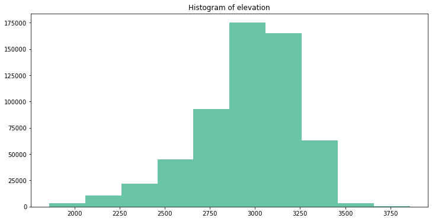

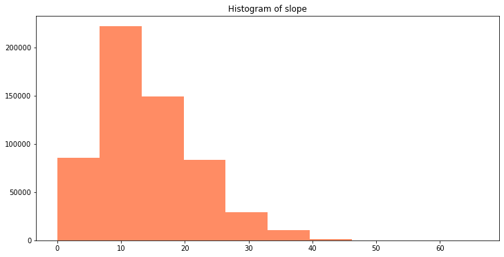

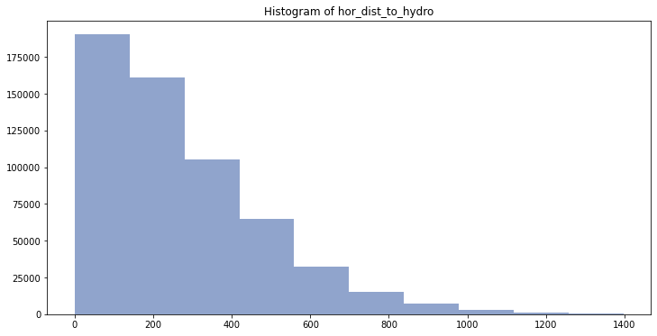

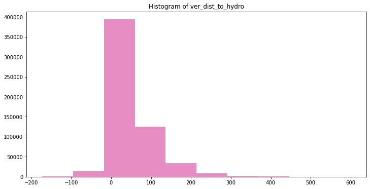

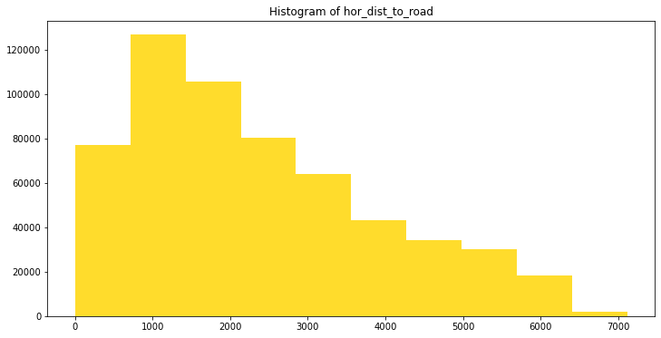

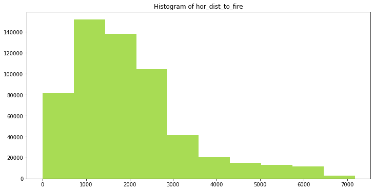

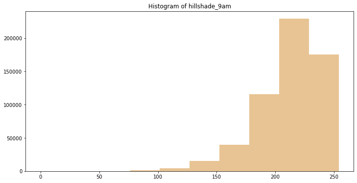

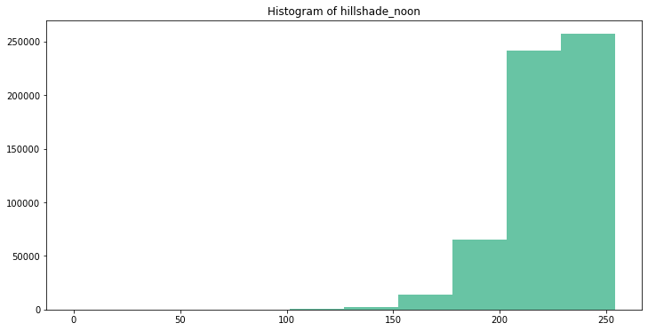

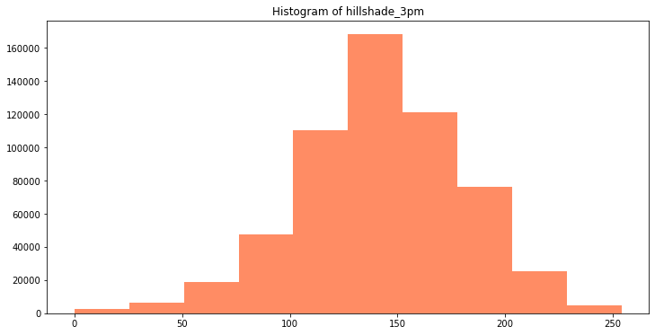

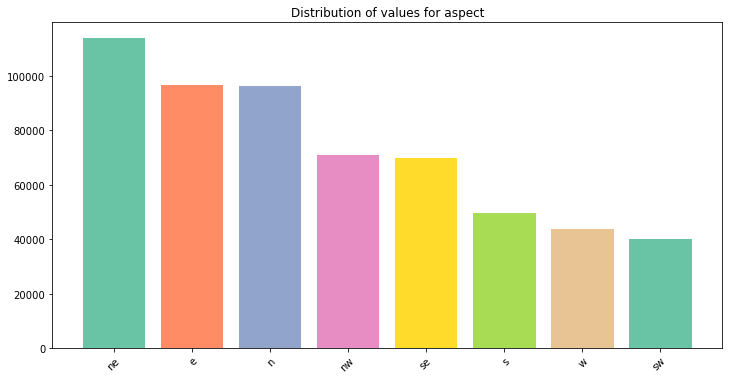

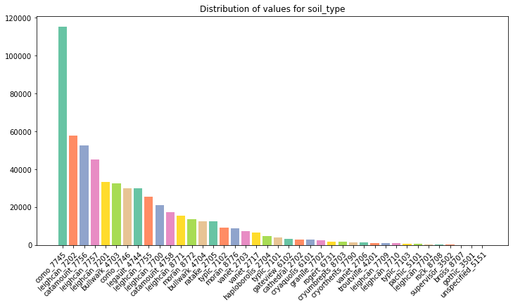

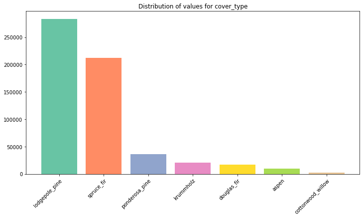

```python
# Interate through features
counter = 0
for feature in decoded_df.columns.tolist():

    # Determine feature type: quantitative or qualitative
    if decoded_df[feature].dtype == "int64":
        # Plot histogram
        plt.rcParams["figure.figsize"] = (12,6)
        plt.figsize = (12,6)
        fig = plt.hist(decoded_df[feature], color=color_list[counter % len(color_list)])
        plt.title("Histogram of {}".format(feature))
        plt.show()
        counter += 1

    elif decoded_df[feature].dtype == "object":
        # Get list of unique values and the count of each
        chart_df = decoded_df[feature]
        value_counts = chart_df.value_counts()
        values = value_counts.index.values.tolist()
        count = value_counts.values.tolist()

        # Plot bar chart
        fig, ax = plt.subplots(figsize=(12, 6))
        ax.bar(values, count, color=color_list)
        plt.setp(ax.get_xticklabels(), rotation=45, ha="right", rotation_mode="anchor")
        ax.set_title("Distribution of values for {}".format(feature))
        plt.show()
```

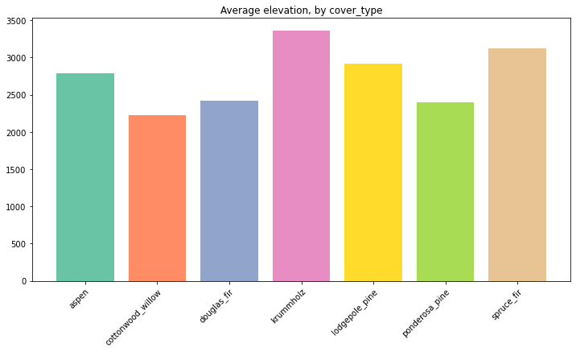

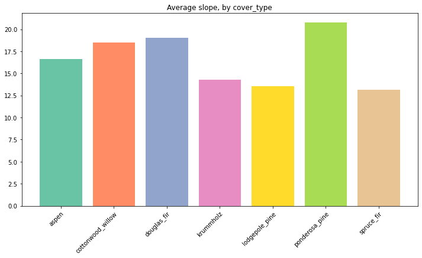

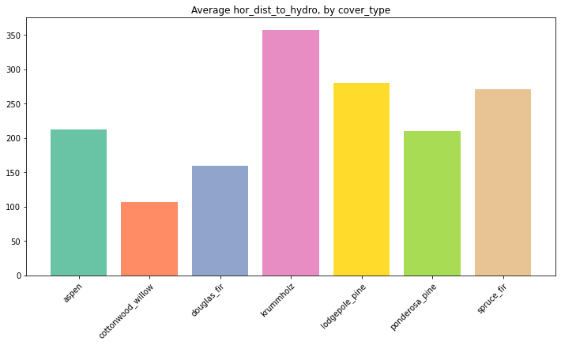

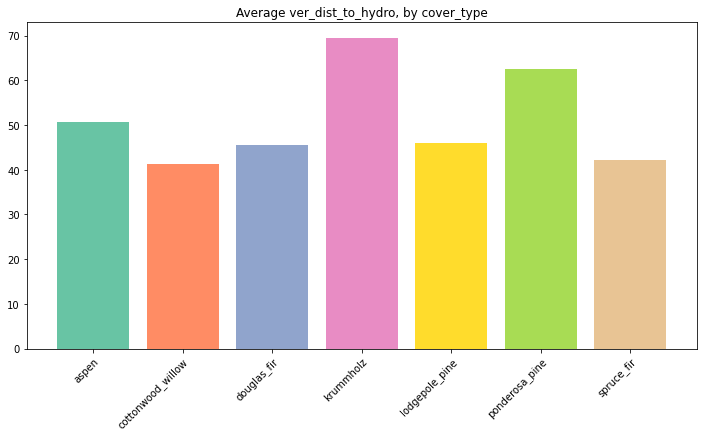

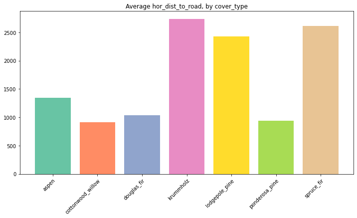

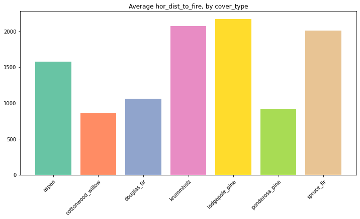

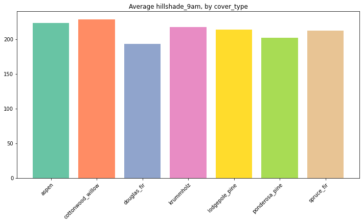

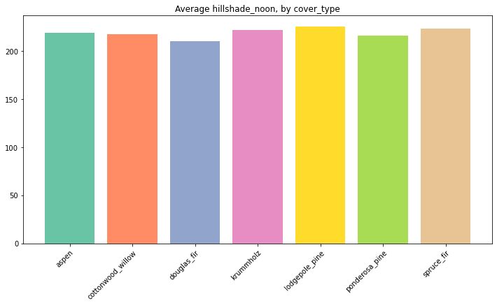

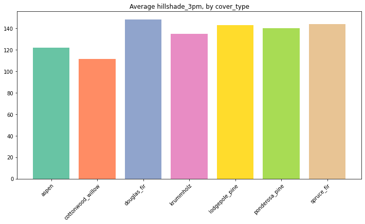

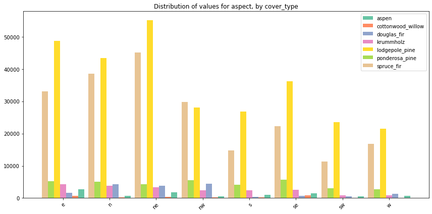

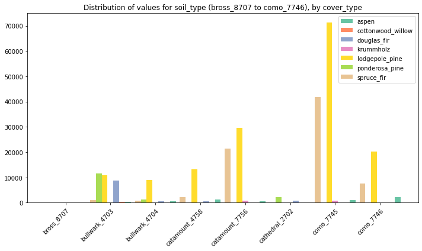

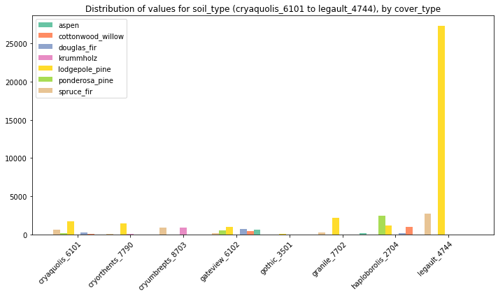

[3 more figures not shown]

```python
# Plot by cover_type
cover_type_list = sorted(decoded_df["cover_type"].unique().tolist())

for feature in decoded_df.drop(["cover_type", "soil_type"], axis=1).columns.tolist():

    # Determine feature type: quantitative or qualitative
    if decoded_df[feature].dtype == "int64":
        #Get averages
        avg_list = []
        for cover_type in cover_type_list:
            sub_df = decoded_df[decoded_df["cover_type"] == cover_type]
            avg_list.append(sub_df[feature].mean())
        # Plot bar chart
        fig, ax = plt.subplots(figsize=(12, 6))
        ax.bar(cover_type_list, avg_list, color=color_list)
        plt.setp(ax.get_xticklabels(), rotation=45, ha="right", rotation_mode="anchor")
        ax.set_title("Average {}, by cover_type".format(feature))
        plt.show()

    elif decoded_df[feature].dtype == "object":
        # Get list of unique values, and the count that have each for each cover_type
        values = sorted(decoded_df[feature].unique().tolist())
        count_list = []
        for cover_type in cover_type_list:
            sub_df = decoded_df[decoded_df["cover_type"] == cover_type]
            sub_list = []
            for value in values:
                sub_list.append(sub_df[sub_df[feature] == value].shape[0])
            count_list.append(sub_list)
        # Plot clustered column graphs
        x = np.arange(len(values))
        width = 0.13
        fig, ax = plt.subplots(figsize=(12, 6))
        offset = -3
        for i in range(len(cover_type_list)):
            ax.bar(x - (width * offset), count_list[i], width, label=cover_type_list[i], color=color_list[i])
            offset += 1
        ax.set_title("Distribution of values for {}, by cover_type".format(feature))
        ax.set_xticks(x)
        ax.set_xticklabels(values)
        plt.setp(ax.get_xticklabels(), rotation=45, ha="right", rotation_mode="anchor")
        ax.legend()
        fig.tight_layout()
        plt.show()

# Plot soil_type splits
soil_type_list = sorted(decoded_df["soil_type"].unique().tolist())
soil_type_split_list = []
for i in range(5):
    soil_type_split_list.append(soil_type_list[i * 8:(i + 1) * 8])

for values in soil_type_split_list:
        # Get list of unique values, and the count that have each for each cover_type
        count_list = []
        for cover_type in cover_type_list:
            sub_df = decoded_df[decoded_df["cover_type"] == cover_type]
            sub_list = []
            for value in values:
                sub_list.append(sub_df[sub_df["soil_type"] == value].shape[0])
            count_list.append(sub_list)

        # Plot clustered column graphs
        x = np.arange(len(values))
        width = 0.13
        fig, ax = plt.subplots(figsize=(10, 6))
        offset = -3
        for i in range(len(cover_type_list)):
            ax.bar(x - (width * offset), count_list[i], width, label=cover_type_list[i], color=color_list[i])
            offset += 1
        ax.set_title("Distribution of values for soil_type ({} to {}), by cover_type".format(values[0], values[-1]))
        ax.set_xticks(x)
        ax.set_xticklabels(values)
        plt.setp(ax.get_xticklabels(), rotation=45, ha="right", rotation_mode="anchor")
        ax.legend()
        fig.tight_layout()
        plt.show()
```

### Distribution of target, as percentages

As it's clear that there is a very uneven distribution of values for the target variable *cover_type*, viewing what percentage of the total each makes up will provide context when measuring model accuracy. E.g. if a particular value makes up 60% of all observations of the target, then simply outputting that value in all future predictions would give a "default" predictive accuracy of 60%  
Conversely, if a a particular value makes up only 1% of all observations, then a model could theoretically never predict that value and still be 99% accurate.

```python
# Calculate and display the distribution of the target variable values as a percetage of the total
chart_df = decoded_df["cover_type"]
value_counts = chart_df.value_counts()
values = value_counts.index.values.tolist()
count = value_counts.values.tolist()
total = decoded_df.shape[0]

for i in range(len(values)):
    print("{}: {}%".format(values[i], round((count[i] / total) * 100, 2)))
```

```
lodgepole_pine: 48.76%
spruce_fir: 36.46%
ponderosa_pine: 6.15%
krummholz: 3.53%
douglas_fir: 2.99%
aspen: 1.63%
cottonwood_willow: 0.47%
```

### Measures of association

Measure of association between pairs of variables are calculated, and plotted on a heatmap.  
Becuase there are two types of variable present, only measures of association between two variables of the same type can be calculated, and a different measure is required for each type:  
association between two continuous variables is measured using a Pearson correlation coefficient,  
association between two categorical variables is measured using Cramér's V

```python
# Define a function  for calculating Cramer's V between two categorical pandas series
def cramers_v(series_1, series_2):
    cross_table = np.array(pd.crosstab(series_1, series_2, rownames=None, colnames=None))
    chi_2 = stats.chi2_contingency(cross_table)[0]
    observations = np.sum(cross_table)
    min_dimensions = min(cross_table.shape)-1
    return round((chi_2 / max(observations * min_dimensions, 1)), 3)
```

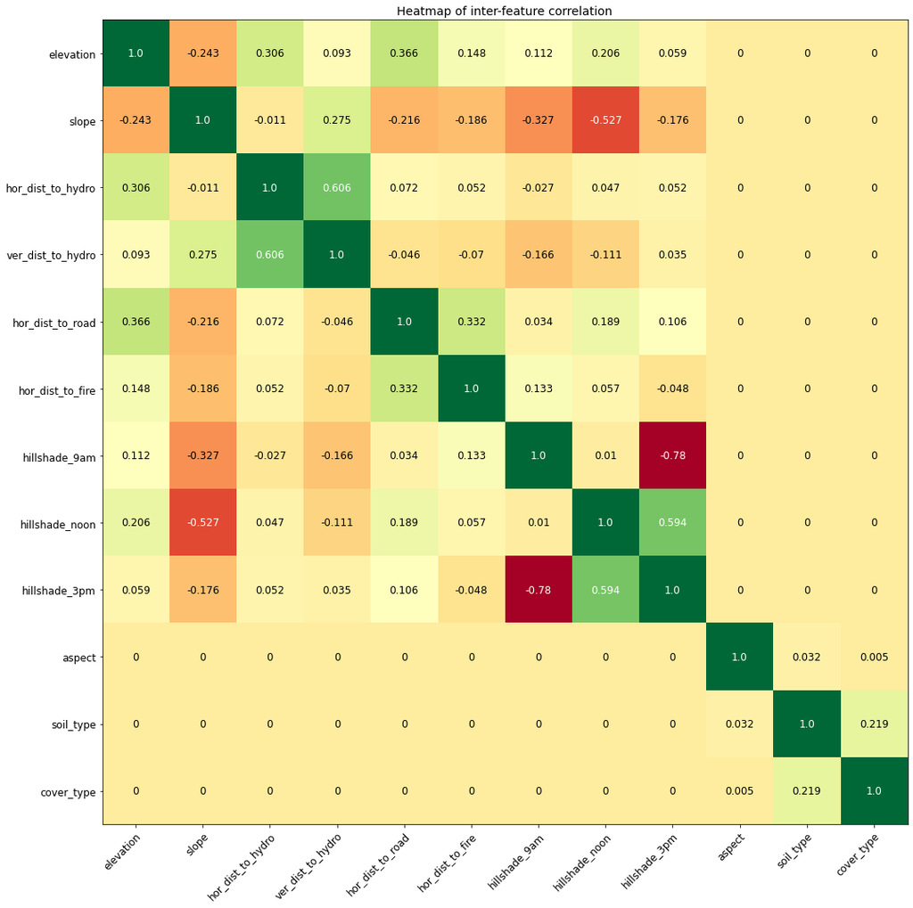

```python
# Initialize and blank list and add to correlation dataframe for future recording of results

# Create a list of features
columns = decoded_df.columns.tolist()

#Initalize an empty list for recording results
association_list = []

# Iterate through columns
for x in columns:
    # Create an empty sub-list for later adding to the cramers_v_list
    sub_list = []
    feature_x = decoded_df[x]

    # Iterate again through columns
    for y in columns:

        # Calculate association based on datatypes of both features and add it to the sub-list.
        feature_y = decoded_df[y]

        if feature_x.dtype == "int64" and feature_y.dtype == "int64":
            association = round(stats.pearsonr(feature_x, feature_y)[0],3)
        elif feature_x.dtype == "object" and feature_y.dtype == "object":
            association = cramers_v(feature_x, feature_y)
        else:
            association = 0
        sub_list.append(association)

    # Add the sub-list to the cramers_v_list
    association_list.append(sub_list)

# Plot a heatmap of Cramer's V between each pair of features
fig, ax = plt.subplots(figsize=(15, 15))
im = ax.imshow(association_list, cmap="RdYlGn")
ax.set_title("Heatmap of inter-feature correlation", fontsize=14)
ax.set_xticks(np.arange(len(columns)))
ax.set_xticklabels(columns, fontsize=12)
ax.set_yticks(np.arange(len(columns)))
ax.set_yticklabels(columns, fontsize=12)
plt.setp(ax.get_xticklabels(), rotation=45, ha="right", rotation_mode="anchor")
for i in range(len(columns)):
    for j in range(len(columns)):
        association = association_list[i][j]
        c = "w" if abs(association) > 0.5 else "k"
        text = ax.text(j, i, association, ha="center", va="center", color=c, fontsize=12)
fig.tight_layout()
plt.show()
```

### Observations

1. There are no null values that require removal or filling
2. The distribution of values in the target *cover_type* is unbalanced. This needs to be kept in mind in later phases, especially when choosing a metric for comparing models, creating train-test splits, and in choosing models and hyperparameters. Another option would be the Synthetic Minority Oversampling Technique, or SMOTE, but it will not be used in this project.
3. The distribution of many of the quantitative independent variables are skewed, so normalisation will be required.
4. The quantitative independent variables have substantially differen scales, so scaling will be required.
5. The data contains the horizontal and vertical distance to the nearest body of water, so the pythagorean distance to the nearest body of water can be calculated.
6. The soil type USFS ELU Code contains 2 additional pieces of information, the climatic zone and geologic zone that might provide more explanatory power than the soil type itself.
7. Categorial variables will need to be re-one-hot-encoded, and *cover_type* will need to be re-label-encoded.

### Output decoded_df for use in the *Extract, Transform, and Load* phase

```python
# Output to csv
file_name = "decoded_cover_type.pkl"
decoded_df.to_pickle(data_dir + file_name)
```